# STA 141A Final Project

James Nguyen

2023-06-08

## Abstract

The project is broken into sections which are as follows: Abstract, Introduction, Background, Descriptive Analysis, Data Integration, Predictive Modeling, and Prediction Performance on the Test Sets. All the analyses revolve around a dataset from Steinmetz et al. (2019), which has been modified for this project to only examine data from 4 different mice across 18 sessions. The project will answer dataset-specific questions along each section, and ultimately lead to the creation of a prediction model for the data at the end.

## Introduction

The objective of this project is to develop a prediction model on the mice’s neural activity that is fairly accurate when tested against the test cases. The implications of this analysis are significant, as they can advance the field of neuroscience and find some relations to Elon Musk’s microchip implementations within the body.

Some questions of interest that will be answered in this project are, “Is there any Homogeneity and Heterogeneity across the Sessions and Mice”, along with several other questions that will be expressed in the following sections.

In this project, the key variables will be the Neurons (the number of neurons), and Brain Area (unique brain area engaged). Based on these two variables a possible hypothesis could be, “Are there any brain areas with a higher quantity of neurons, and if so during which activity does it cause this effect?”.

## Background

As stated before, the data utilized in this project will only look at 4 different mice across 18 sessions, compared to the full experiment by Steinmetz which has a total of 10 mice across 39 sessions. All of the variables such as brain area and neurons were recorded by having the mice wear this sort of “headset” that measures all of their neural activity while the mice perform a set task. Depending on the mice’s performance/decision, the researchers would label either success or failure by 1 or -1, respectively, which form the dataset we have today. That includes all these various neural activities and data, which will be used to analyze and form a prediction model.

## Descriptive Analysis

Table 1: Data Structure Across Sessions

| Mouse Name | Brain Area | Neurons | Trials | Success Rate |
| --- | --- | --- | --- | --- |
| Cori | 8 | 734 | 114 | 0.61 |
| Cori | 5 | 1070 | 251 | 0.63 |
| Cori | 11 | 619 | 228 | 0.66 |
| Forssmann | 11 | 1769 | 249 | 0.67 |
| Forssmann | 10 | 1077 | 254 | 0.66 |
| Forssmann | 5 | 1169 | 290 | 0.74 |
| Forssmann | 8 | 584 | 252 | 0.67 |
| Hench | 15 | 1157 | 250 | 0.64 |
| Hench | 12 | 788 | 372 | 0.69 |
| Hench | 13 | 1172 | 447 | 0.62 |
| Hench | 6 | 857 | 342 | 0.80 |
| Lederberg | 12 | 698 | 340 | 0.74 |
| Lederberg | 15 | 983 | 300 | 0.80 |
| Lederberg | 10 | 756 | 268 | 0.69 |
| Lederberg | 8 | 743 | 404 | 0.76 |
| Lederberg | 6 | 474 | 280 | 0.72 |
| Lederberg | 6 | 565 | 224 | 0.83 |
| Lederberg | 10 | 1090 | 216 | 0.81 |

### (i) Describe The Data Structures Across Sessions

From table 1, we can see that there are eighteen sessions conducted with four mice. The variables used in the analysis are as follows: Mouse (specifying the mouse’s name for each session), Brain Area (representing the unique brain area involved), Neurons (referring to the number of neurons), Trials (denoting the number of trials per session), and Success Rate (indicating the ratio of successful trials to the total number of trials). It is also worth noting that the chosen data does not contain any missing values (Table 1).

```
##      CA1       DG       LP       MG      MRN       NB     POST     root
## 2.738095 4.058824 4.500000 2.722628 5.634146 1.674419 1.111111 1.166667
##      SPF    VISam     VISp
## 4.600000 2.061404 1.324561
```

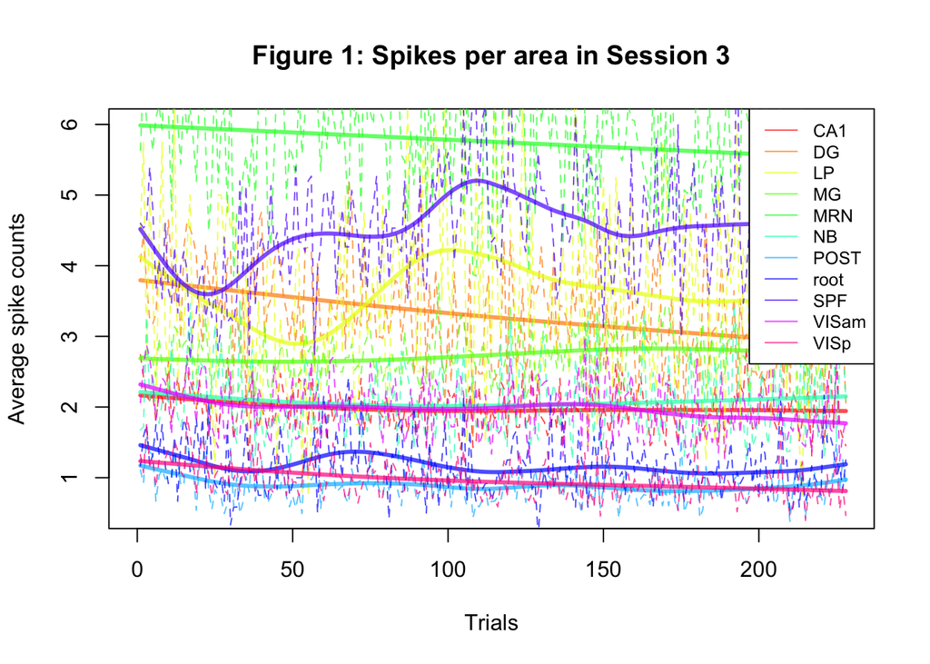

### (ii) Explore The Neural Activities During Each Trial

In Figure 1, which represents the average spike count across trials in session 3, I specifically chose this session due to its inclusion diverse spread of neurons. When comparing sessions 1-6, every session had low neuron activity which made it harder to visualize the spikes, excluding session 3. Examining the figure, it is evident that the average spike counts of SPF and LP display consistent fluctuations throughout the trials, while the other neurons display relatively stable spike counts, compared to SPF and LP.

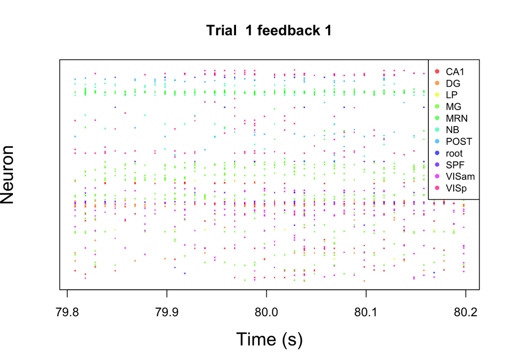

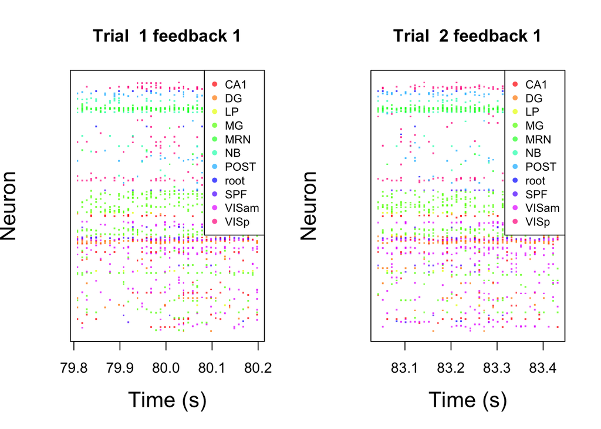

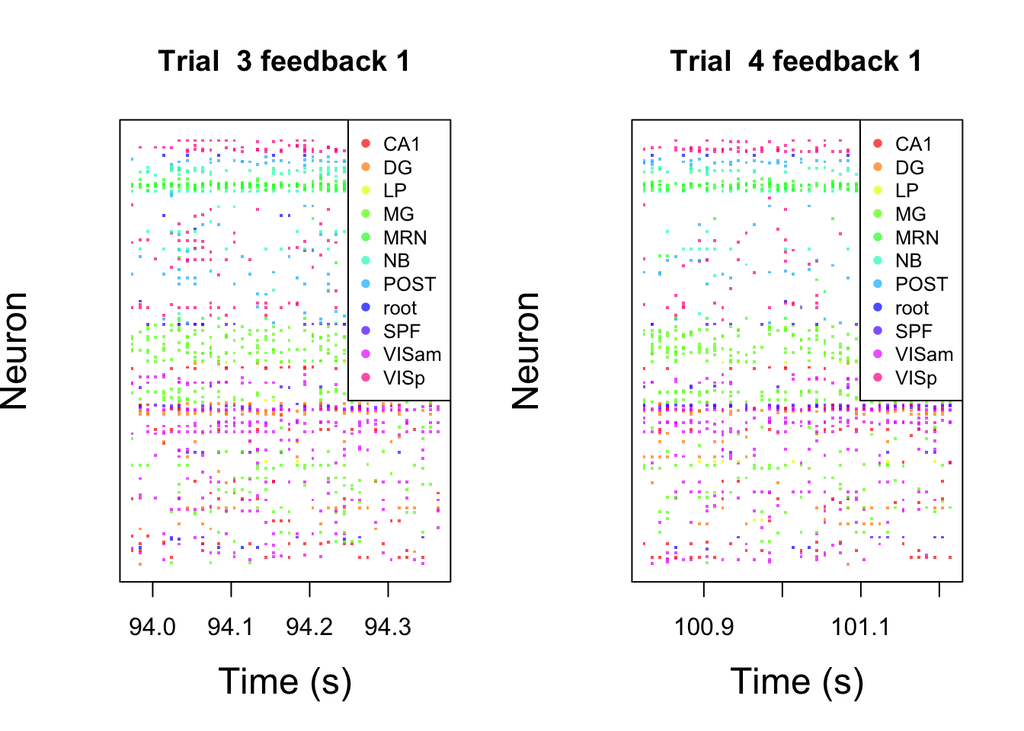

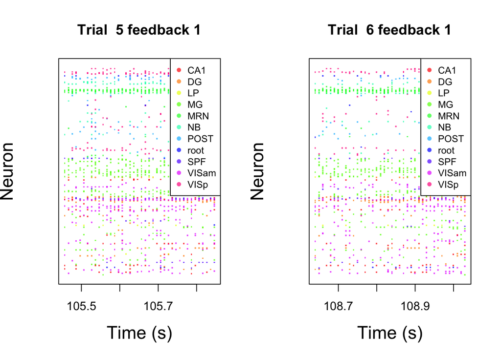

### (iii) Explore The Changes Across Trials

Here we are comparing the feedback 1 of 6 different trials. I believe that neuron MG is the most stable across the 6 trials examined. While the neuron NB & VISam is the least stable with noticeable changes between each trial.

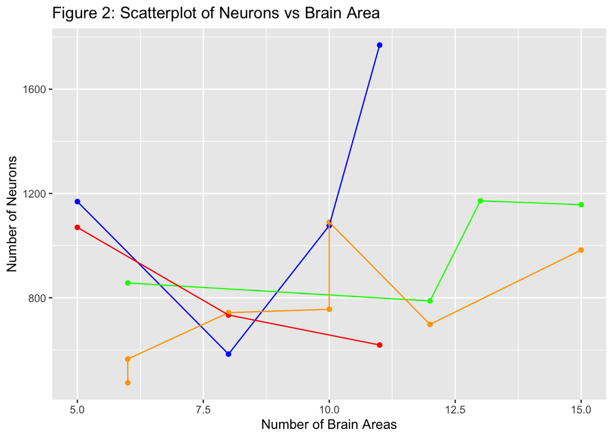

### (iv) Explore Homogeneity and Heterogeneity Across Sessions and Mice.*

In Figure 2, we can see the correlation between the number of neurons and the number of brain areas. Each session is represented by a dot on the plot, and the colors indicate different mouses. Cori is in Red, Forssmann in Blue, Hench in Green, and Lederberg in Orange. We can also double-check these by referencing Table 1 from before to make sure these colors corresponded to the respective mouse.

We can find both similarities and differences across the sessions and mice. The similarities, or homogeneity, are evident in the initial section of the plot, where both Cori and Forssmann exhibit a decrease in the number of neurons as the number of brain areas increases. Conversely, the differences, or heterogeneity, become apparent in the middle portion of the graph. Where Lederberg’s number of neurons increases while the number of brain areas remains constant, which makes it unique from the other mice.

## Data Integration

### (i) Extracting The Shared Patterns Across Sessions

Here I calculated the average spike counts for each trial in every session. By examining the common trend represented by the average spike counts across all sessions, we can identify shared patterns and ignore variations in the neuron-characteristics, etc. The average spike counts serve as a collective representation of neural activity, enabling us to capture consistent patterns that emerge across multiple sessions. In conclusion, a comprehensive data frame is constructed, encompassing all the predictors and outcomes for building a predictive model in the next section.

## Predictive Modeling

```
## Logistic Regression Model Summary:
```

```
##
## Call:
## glm(formula = feedback_type_all ~ avg_spikes_all + contrast_left_all +
##     contrast_right_all, family = "binomial", data = train_data)
##
## Deviance Residuals:
##     Min       1Q   Median       3Q      Max
## -1.6807  -1.3274   0.8546   0.9429   1.2374
##
## Coefficients:
##                    Estimate Std. Error z value Pr(>|z|)
## (Intercept)          0.3163     0.3925   0.806   0.4202
## avg_spikes_all       0.3217     0.2355   1.366   0.1720
## contrast_left_all    0.0928     0.3310   0.280   0.7792
## contrast_right_all  -0.6886     0.3049  -2.258   0.0239 *
## ---
## Signif. codes:  0 '***' 0.001 '**' 0.01 '*' 0.05 '.' 0.1 ' ' 1
##
## (Dispersion parameter for binomial family taken to be 1)
##
##     Null deviance: 392.05  on 299  degrees of freedom
## Residual deviance: 386.14  on 296  degrees of freedom
## AIC: 394.14
##
## Number of Fisher Scoring iterations: 4
```

```
##
## Confusion Matrix:
```

```
##     predicted
## true    0    1
##    0   66 1299
##    1  121 3295
```

```
##
## Misclassification Error Rate: 0.297009
```

## Prediction Performance On The Test Sets

```
## Logistic Regression Model Summary:
```

```
##
## Call:
## glm(formula = as.factor(feedback_type_all_test) ~ avg_spikes_all_test +
##     contrast_left_all_test + contrast_right_all_test, family = "binomial",
##     data = train_data)
##
## Deviance Residuals:
##     Min       1Q   Median       3Q      Max
## -1.9842  -1.3396   0.7178   0.8717   1.2029
##
## Coefficients:
##                         Estimate Std. Error z value Pr(>|z|)
## (Intercept)             -0.89719    0.72326  -1.240  0.21479
## avg_spikes_all_test      1.60698    0.58654   2.740  0.00615 **
## contrast_left_all_test   0.02751    0.43765   0.063  0.94988
## contrast_right_all_test -0.47327    0.41062  -1.153  0.24908
## ---
## Signif. codes:  0 '***' 0.001 '**' 0.01 '*' 0.05 '.' 0.1 ' ' 1
##
## (Dispersion parameter for binomial family taken to be 1)
##
##     Null deviance: 235.27  on 199  degrees of freedom
## Residual deviance: 226.21  on 196  degrees of freedom
## AIC: 234.21
##
## Number of Fisher Scoring iterations: 4
```

```
##
## Confusion Matrix:
```

```
##     predicted
## true   0   1
##    0   1  54
##    1   1 144
```

```
##
## Misclassification Error Rate: 0.275
```

## Discussion

To enhance the model, I would experiment with different combinations of predictors in the logistic regression model, and compare them to the full model to determine which predictor is beneficial to the model; potentially improving the model’s predictive performance. Another method that would work would be to utilize PCAs (Principal Component Analysis), which would help capture more relevant patterns.

## Acknowledgements

ChatGPT, Consulting Sessions Code, Discussion 10, Assignment 4

## Code Appendix

```r
library(tidyverse)
library(knitr)
library(dplyr)
session <- list()
for (i in 1:18) {
  session[[i]]=readRDS(paste("~/Downloads/sessions/session",i,'.rds',sep=''))
}

n.session <- length(session)
# in tidyverse
meta <- tibble(
  mouse_name = rep('name',n.session),

  n_brain_area = rep(0,n.session),
  n_neurons = rep(0,n.session),
  n_trials = rep(0,n.session),
  success_rate = rep(0,n.session)
)


for(i in 1:n.session){
  tmp = session[[i]];
  meta[i,1]=tmp$mouse_name;

  meta[i,2]=length(unique(tmp$brain_area));
  meta[i,3]=dim(tmp$spks[[1]])[1];
  meta[i,4]=length(tmp$feedback_type);
  meta[i,5]=mean(tmp$feedback_type+1)/2;

  }

kable(meta, format = "html",table.attr = "class='table table-striped'",digits = 2,caption = "Table 1: Data Structure Across Sessions",
      col.names = c("Mouse Name", "Brain Area", "Neurons", "Trials", "Success Rate"))

# indicator for this session
i.s=3

# indicator for this trial
i.t=1

spk.trial = session[[i.s]]$spks[[i.t]]
area=session[[i.s]]$brain_area

# We need to first calculate the number of spikes for each neuron during this trial
spk.count=apply(spk.trial,1,sum)

# tapply():
spk.average.tapply=tapply(spk.count, area, mean)

# dplyr:
# To use dplyr you need to create a data frame
tmp_2 <- data.frame(
  area = area,
  spikes = spk.count
)

# Calculate the average by group using dplyr
spk.average.dplyr =tmp_2 %>%
  group_by(area) %>%
  summarize(mean= mean(spikes))



# Wrapping up the function:
average_spike_area<-function(i.t,this_session){
  spk.trial = this_session$spks[[i.t]]
  area= this_session$brain_area
  spk.count=apply(spk.trial,1,sum)
  spk.average.tapply=tapply(spk.count, area, mean)
  return(spk.average.tapply)
  }

# Test the function
average_spike_area(1,this_session = session[[i.s]])
n.trial=length(session[[i.s]]$feedback_type)
n.area=length(unique(session[[i.s]]$brain_area ))
# Alternatively, you can extract these information in the meta that we created before.

# We will create a data frame that contain the average spike counts for each area, feedback type,  the two contrasts, and the trial id
trial.summary =matrix(nrow=n.trial,ncol= n.area+1+2+1)
for(i.t in 1:n.trial){
  trial.summary[i.t,]=c(average_spike_area(i.t,this_session = session[[i.s]]),
                          session[[i.s]]$feedback_type[i.t],
                        session[[i.s]]$contrast_left[i.t],
                        session[[i.s]]$contrast_right[i.s],
                        i.t)
}

colnames(trial.summary)=c(names(average_spike_area(i.t,this_session = session[[i.s]])), 'feedback', 'left contr.','right contr.','id' )

# Turning it into a data frame
trial.summary <- as_tibble(trial.summary)
area.col=rainbow(n=n.area,alpha=0.7)
plot(x=1,y=0, col='white',xlim=c(0,n.trial),ylim=c(0.5,6), xlab="Trials",ylab="Average spike counts", main=paste("Figure 1: Spikes per area in Session", i.s))


for(i in 1:n.area){
  lines(y=trial.summary[[i]],x=trial.summary$id,col=area.col[i],lty=2,lwd=1)
  lines(smooth.spline(trial.summary$id, trial.summary[[i]]),col=area.col[i],lwd=3)
  }
legend("topright",
  legend = colnames(trial.summary)[1:n.area],
  col = area.col,
  lty = 1,
  cex = 0.8
)
plot.trial<-function(i.t,area, area.col,this_session){

    spks=this_session$spks[[i.t]];
    n.neuron=dim(spks)[1]
    time.points=this_session$time[[i.t]]

    plot(0,0,xlim=c(min(time.points),max(time.points)),ylim=c(0,n.neuron+1),col='white', xlab='Time (s)',yaxt='n', ylab='Neuron', main=paste('Trial ',i.t, 'feedback', this_session$feedback_type[i.t] ),cex.lab=1.5)
    for(i in 1:n.neuron){
        i.a=which(area== this_session$brain_area[i]);
        col.this=area.col[i.a]

        ids.spike=which(spks[i,]>0) # find out when there are spikes
        if( length(ids.spike)>0 ){
            points(x=time.points[ids.spike],y=rep(i, length(ids.spike) ),pch='.',cex=2, col=col.this)
        }
    }
legend("topright",
  legend = area,
  col = area.col,
  pch = 16,
  cex = 0.8
  )
  }
varname=names(trial.summary);
area=varname[1:(length(varname)-4)]
plot.trial(1,area, area.col,session[[i.s]])
varname=names(trial.summary);
area=varname[1:(length(varname)-4)]
par(mfrow=c(1,2))
plot.trial(1,area, area.col,session[[i.s]])
plot.trial(2,area, area.col,session[[i.s]])
plot.trial(3,area, area.col,session[[i.s]])
plot.trial(4,area, area.col,session[[i.s]])
plot.trial(5,area, area.col,session[[i.s]])
plot.trial(6,area, area.col,session[[i.s]])
# Convert meta to a data frame
meta_df <- data.frame(n_brain_area = meta[, 2], n_neurons = meta[, 3])

# Create a new vector for colors
colors <- c(rep("red", 3), rep("blue", 4), rep("green", 4), rep("orange", 7))

# If there are more points, assign them a default color
colors <- c(colors, rep("gray", max(0, nrow(meta_df) - length(colors))))

# Add the colors to the data frame
meta_df$color <- colors

ggplot(meta_df, aes(x = n_brain_area, y = n_neurons, color = color, group = color)) +
  geom_point() +
  geom_line() +
  scale_color_identity() +
  labs(x = "Number of Brain Areas", y = "Number of Neurons", title = "Figure 2: Scatterplot of Neurons vs Brain Area")

avg_spikes_all <- lapply(session, function(curr_session) {
  avg_spikes_session <- sapply(curr_session$spks, function(spikes) {
    mean(rowSums(spikes))
  })
  unlist(avg_spikes_session)
})

avg_spikes_all <- unlist(avg_spikes_all)
contrast_left_all <- unlist(lapply(session, `[[`, "contrast_left"))
contrast_right_all <- unlist(lapply(session, `[[`, "contrast_right"))
feedback_type_all <- unlist(lapply(session, `[[`, "feedback_type"))

data <- data.frame(avg_spikes_all, contrast_left_all, contrast_right_all, feedback_type_all)
data$feedback_type_all <- ifelse(data$feedback_type_all == -1, 0, 1)

# Set a seed for reproducibility
set.seed(12)

# Randomly select training indices based on seed
train_indices <- sample(1:700, size = 300)

# Divide the data into training and test sets
train_data <- data[train_indices, ]
test_data <- data[-train_indices, ]

# Fitting a logistic regression model
logistic_model <- glm(feedback_type_all ~ avg_spikes_all + contrast_left_all + contrast_right_all,
                      data = train_data, family = "binomial")

# Print the model summary
cat("Logistic Regression Model Summary:\n")
summary(logistic_model)

# Make predictions on the test set
probabilities <- predict(logistic_model, newdata = test_data, type = "response")

# Convert probabilities to class labels
predictions <- as.factor(ifelse(probabilities > 0.5, 1, 0))

# Create a confusion matrix to evaluate model performance
confusion_matrix <- table(true = test_data$feedback_type_all, predicted = predictions)

# Print the confusion matrix
cat("\nConfusion Matrix:\n")
print(confusion_matrix)

# Compute the misclassification error rate
misclassification_rate <- sum(confusion_matrix[1, 2], confusion_matrix[2, 1]) / sum(confusion_matrix)

# Print the misclassification error rate
cat("\nMisclassification Error Rate:", misclassification_rate, "\n")

# Read in the test sessions
test_session <- list()
for (i in 1:2) {
  test_session[[i]] <- readRDS(paste("~/Downloads/test/test", i, ".rds", sep = ""))
}

# Calculate average spikes for each of the sessions
avg_spikes_all_test <- lapply(test_session, function(session) {
  avg_spikes_session_test <- sapply(session$spks, function(spikes) mean(rowSums(spikes)))
  unlist(avg_spikes_session_test)
})
avg_spikes_all_test <- unlist(avg_spikes_all_test)

# Extract other variables
contrast_left_all_test <- unlist(lapply(test_session, function(x) x$contrast_left))
contrast_right_all_test <- unlist(lapply(test_session, function(x) x$contrast_right))
feedback_type_all_test <- unlist(lapply(test_session, function(x) x$feedback_type))

# Create the test data frame
test_data <- data.frame(
  avg_spikes_all_test,
  contrast_left_all_test,
  contrast_right_all_test,
  feedback_type_all_test
)
test_data$feedback_type_all_test <- ifelse(test_data$feedback_type_all_test == -1, 0, 1)

# Fitting the logistic regression model
logistic_model_2 <- glm(
  as.factor(feedback_type_all_test) ~ avg_spikes_all_test + contrast_left_all_test + contrast_right_all_test,
  data = train_data,
  family = "binomial"
)

# Summarize the model
cat("Logistic Regression Model Summary:\n")
summary(logistic_model_2)

# Make predictions on the test set
probabilities_2 <- predict(logistic_model_2, newdata = test_data, type = "response")

# Convert probabilities to class labels
predictions_2 <- as.factor(ifelse(probabilities_2 > 0.5, 1, 0))

# Create a confusion matrix to evaluate model performance
confusion_matrix_2 <- table(true = test_data$feedback_type_all_test, predicted = predictions_2)

# Print the confusion matrix
cat("\nConfusion Matrix:\n")
print(confusion_matrix_2)

# Compute the misclassification error rate
misclassification_rate_2 <- sum(confusion_matrix_2[1, 2], confusion_matrix_2[2, 1]) / sum(confusion_matrix_2)

# Print the misclassification error rate
cat("\nMisclassification Error Rate:", misclassification_rate_2, "\n")
```